# Problema 1 - Checkpoint 3

Arthur Vinícius Tomé Rodrigues

May 6, 2018

Nesta análise, utilizaremos os dados de todas as séries.

```r
dados = read_csv(here("data/series_from_imdb.csv"),
                    progress = FALSE,
                    col_types = cols(.default = col_double(),
                                     series_name = col_character(),
                                     episode = col_character(),
                                     url = col_character(),
                                     season = col_character()))
```

## Relação entre número de episódios e avaliação

Existe alguma relação entre a quantidade de episódios de uma série e sua avaliação geral dentre os usuários? Séries mais longas ou mais curtas são mais amadas?

Temos, para cada série, a nota dada pelos usuários em cada episódio. Vamos definir a **média** dessas notas (para a série como um todo) sendo sua avaliação geral.

Vamos gerar também uma nova variável (**total_ep**), representando a quantidade de episódios de cada série.

```r
media_por_eps = dados %>%
                group_by(series_name) %>%
                summarise(media = mean(user_rating), total_ep = max(series_ep))
media_por_eps
```

| series_name | media | total_ep |
| --- | --- | --- |
| 100 Questions | 6.900000 | 6 |
| 11.22.63 | 8.425000 | 8 |
| 12 Monkeys | 8.755556 | 36 |
| 13 Reasons Why | 8.653846 | 13 |
| 18 To Life | 6.812000 | 25 |
| 24 Horas | 8.560000 | 195 |
| 2 Broke Girls | 7.249635 | 137 |
| 30 Rock | 8.129197 | 137 |
| 90210 | 7.438596 | 114 |
| Accidentally on Purpose | 7.350000 | 18 |

[output cut: 501 more lines]

Vejamos graficamente a relação entre essas duas variáveis.

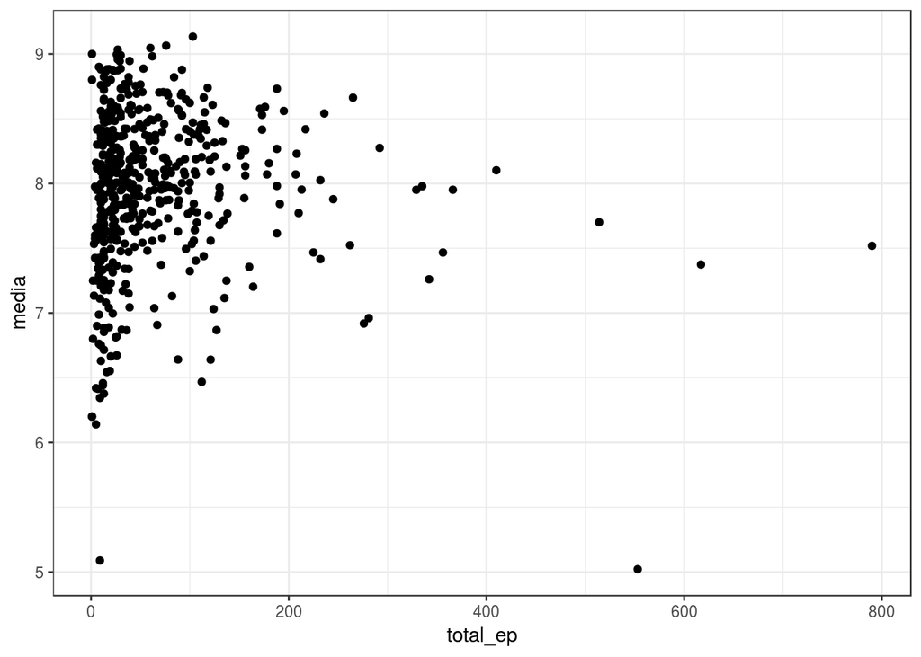

```r
media_por_eps %>%
    ggplot(aes(x = total_ep, y = media)) +
    geom_point()
```

Analisando o gráfico, podemos concluir que a avaliação das séries independe do número de episódios.

A variação na avaliação dada pelos usuários é bem alta, não importando se as séries são curtas ou longas.

Vamos então confirmar, numericamente, através de cálculo de correlação linear, se essa conclusão é correta.

```r
media_por_eps %>%
    summarise(correlacao_linear = cor(total_ep, media,
                                      method = "pearson"))
```

| correlacao_linear |
| --- |
| -0.04350018 |

A correlação entra as duas variáveis é quase nula, ou seja, elas estão fracamente relacionadas.

Enfim, podemos descartar a quantidade de episódios como sendo um fator que define se a série será ou não amada pelo público.

“A perfeição não consiste na quantidade, mas na qualidade.”

### **Como varia a quantidade de episódios nas séries?**

Não pude deixar de notar, através do gráfico gerado anteriormente, que os dados são bastante concentrados à esquerda.

Apesar de existirem séries com quase 800 episódios, uma grande porcentagem das séries possui uma quantidade bem menor.

Vejamos então como varia a quantidade de episódios nas séries.

```r
summary(media_por_eps$total_ep)
```

```
##    Min. 1st Qu.  Median    Mean 3rd Qu.    Max.
##    1.00   18.00   36.00   62.76   80.50  790.00
```

Temos então que 50% das séries tem 36 ou menos episódios (informação obtida através da mediana), enquanto a série mais longa possui 790 episódios, um aumento de quase 2200% em relação a mediana.

Graficamente,

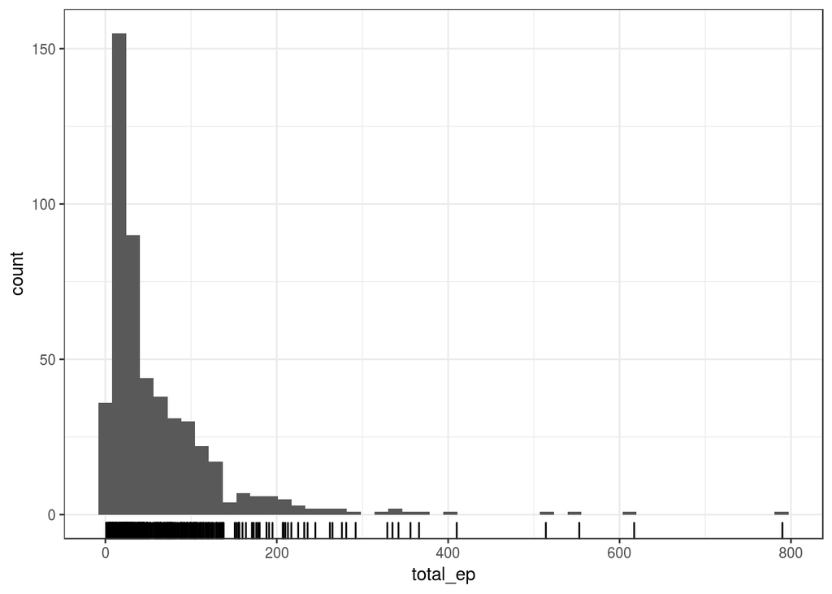

```r
ggplot(media_por_eps, mapping = aes(x = total_ep)) +
    geom_histogram(bins = 50) +
    geom_rug()
```

## Séries mais famosas

Quais são as 3 séries mais famosas/assistidas?

Temos, para cada série, a quantidade de votos de usuários para cada episódio.

Vamos assumir que quanto mais votos, mais pessoas assistem a série. Logo, as séries que desejamos devem possuir a maior quantidade de votos.

Porém, a quantidade de votos apresentada nos dados é referente a cada episódio, vamos então criar uma nova variável (**fama**), que será a média do número de votos ao longo da série.

```r
series_fame = dados %>%
                group_by(series_name) %>%
                summarise(fame = mean(user_votes))
series_fame
```

| series_name | fame |
| --- | --- |
| 100 Questions | 17.333333 |
| 11.22.63 | 1706.625000 |
| 12 Monkeys | 452.305556 |
| 13 Reasons Why | 2888.846154 |
| 18 To Life | 10.200000 |
| 24 Horas | 787.200000 |
| 2 Broke Girls | 274.671533 |
| 30 Rock | 500.569343 |
| 90210 | 97.798246 |
| Accidentally on Purpose | 48.500000 |

[output cut: 501 more lines]

Agora, vamos ordenar as séries em relação à fama, em ordem decrescente. Assim teremos as 3 séries desejadas.

```r
arrange(series_fame, desc(fame))
```

| series_name | fame |
| --- | --- |
| Game of Thrones | 22073.516667 |
| Sherlock | 19429.733333 |
| Breaking Bad | 12531.870968 |
| Black Mirror | 12519.846154 |
| True Detective | 9032.937500 |
| The Walking Dead | 8281.535354 |
| Stranger Things | 7753.125000 |
| Daredevil | 5245.230769 |
| Mr Robot | 4469.454545 |
| Better Call Saul | 4354.888889 |

[output cut: 501 more lines]

Obtemos assim, que as 3 séries mais famosas são: **Game of Thrones**, **Sherlock** e **Breaking Bad**.

### Sendo as séries mais famosas, elas são as melhores/mais amadas?

É intuitivo pensar que as séries mais famosas possuem as melhores avaliações, vejamos então se isso é verdade.

Vamos inicialmente calcular a avaliação geral dessas séries.

```r
media_famous_series = dados %>%
                        filter(series_name %in% c("Game of Thrones", "Sherlock", "Breaking Bad")) %>%
                        group_by(series_name) %>%
                        summarise(media = mean(user_rating))
media_famous_series
```

| series_name | media |
| --- | --- |
| Breaking Bad | 8.982258 |
| Game of Thrones | 9.046667 |
| Sherlock | 8.866667 |

Temos que a série mais famosa possui, como avaliação geral, 9.04. As 2 outras séries possuem notas bem próximas, sendo a menor delas 8.86.

Mas, será que essas são as séries mais bem avaliadas dentre todas? Ou pelo menos estão entre as melhores?

Vejamos então como varia a avaliação das séries.

```r
var_media = dados %>%
                group_by(series_name) %>%
                summarise(media = mean(user_rating))

var_media %>% summary(media)
```

```
##  series_name            media
##  Length:511         Min.   :5.022
##  Class :character   1st Qu.:7.656
##  Mode  :character   Median :8.046
##                     Mean   :7.966
##                     3rd Qu.:8.376
##                     Max.   :9.134
```

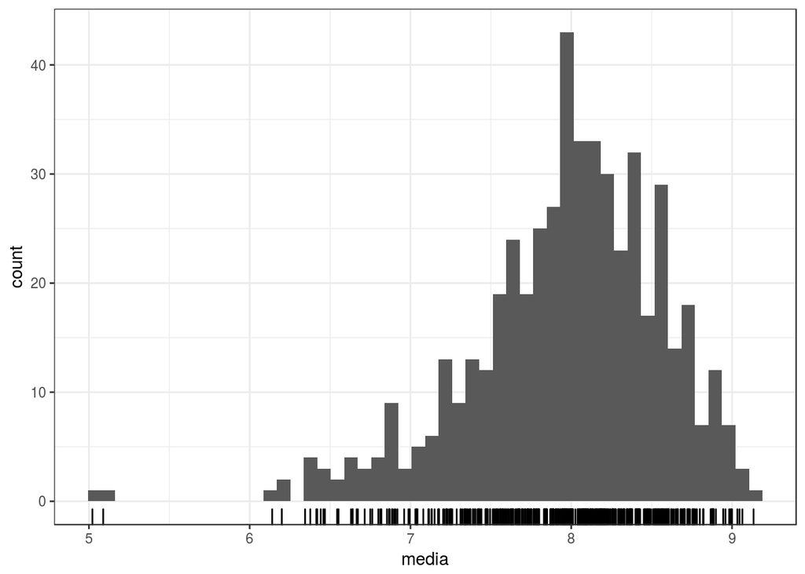

```r
ggplot(var_media, mapping = aes(x = media)) +
    geom_histogram(bins = 50) +
    geom_rug()
```

Temos que tanto a média como a mediana das avaliações é de aproximadamente 8. As notas das séries mais famosas estão bem acima disso, e chegam bem próximo da nota máxima, que é 9.134.

Podemos ver também, através do gráfico, que uma pequena porcentagem das séries possui avaliação tão alta quanto as séries famosas (> 8.86). E quanto exatamente é essa porcetagem?

```r
better_series = var_media %>% filter(media > 8.86)

quant_high_medias = nrow(better_series)
perc = quant_high_medias / nrow(var_media) * 100.0
```

```r
quant_high_medias
```

```
## [1] 23
```

```r
perc
```

```
## [1] 4.500978
```

Logo, apesar das 3 séries mais famosas não serem exatamente as 3 séries com maior avaliação, elas estão entre as 23 mais bem avaliadas, o que representa apenas 4.5% das séries.